# Analyzing Student Dropouts

### XGBoost

```python
X_train_xgb, X_test_xgb, y_train_xgb, y_test_xgb = train_test_split(X, y, test_size=0.3)
# Creating Classifier - XGBoost
accuracy_xgb = dict()
xgb_models = dict()
for trees in range(2, 30):
    clf_xgb = XGBClassifier(n_estimators=trees)
    clf_xgb.fit(X_train_xgb,y_train_xgb)
    xgb_models[trees] = clf_xgb
    y_pred_xgb=clf_xgb.predict(X_test_xgb)
    accuracy_xgb[trees] = accuracy_score(y_test_xgb, y_pred_xgb)
accuracy_xgb = dict(sorted(accuracy_xgb.items(),key=(lambda x: x[1]), reverse= True))
accuracy_xgb
```

```
{8: 0.8648363252375924,
 6: 0.8637803590285111,
 7: 0.8637803590285111,
 12: 0.8637803590285111,
 5: 0.8627243928194298,
 11: 0.8627243928194298,
 14: 0.8627243928194298,
 16: 0.8627243928194298,
 9: 0.8616684266103485,
 13: 0.8616684266103485,
 17: 0.8616684266103485,
 19: 0.8616684266103485,
 15: 0.8606124604012672,
 18: 0.8606124604012672,
 10: 0.8585005279831045,
 4: 0.8574445617740233,
 20: 0.8574445617740233,
 3: 0.8553326293558606,
 21: 0.8542766631467793,
 22: 0.8542766631467793,
 28: 0.8542766631467793,
 26: 0.853220696937698,
 27: 0.853220696937698,
 29: 0.853220696937698,
 2: 0.8521647307286166,
 25: 0.8521647307286166,
 23: 0.8511087645195353,
 24: 0.8511087645195353}
```

```python
for model in accuracy_xgb:
    y_pred_xgb=xgb_models[model].predict(X_test_xgb)
    confusion_matrix_xgb = pd.crosstab(y_test_xgb, y_pred_xgb, rownames=['Actual'], colnames=['Predicted'])
    print('Accuracy for i = {}: {} '.format(model, round(accuracy_score(y_test_xgb, y_pred_xgb), 4)))
    print(confusion_matrix_xgb)
```

```
Accuracy for i = 8: 0.8648
Predicted    0    1
Actual
0          563   36
1           92  256
Accuracy for i = 6: 0.8638
Predicted    0    1
Actual
0          565   34
1           95  253
Accuracy for i = 7: 0.8638
Predicted    0    1
Actual
0          563   36
1           93  255
Accuracy for i = 12: 0.8638
Predicted    0    1
Actual
0          560   39
1           90  258
Accuracy for i = 5: 0.8627
Predicted    0    1
Actual
0          564   35
1           95  253
Accuracy for i = 11: 0.8627
Predicted    0    1
Actual
0          559   40
1           90  258
Accuracy for i = 14: 0.8627
Predicted    0    1
Actual
0          559   40
1           90  258
Accuracy for i = 16: 0.8627
Predicted    0    1
Actual
0          559   40
1           90  258
```

[output cut: 85 more lines]

```
Accuracy for i = 25: 0.8522
Predicted    0    1
Actual
0          551   48
1           92  256
Accuracy for i = 23: 0.8511
Predicted    0    1
Actual
0          551   48
1           93  255
Accuracy for i = 24: 0.8511
Predicted    0    1
Actual
0          550   49
1           92  256
```

```
model =  XGBoost 	dataset =  Unbalanced
Accuracy: 0.8522
Precision: 0.8127
Recall: 0.7431
F1 Score: 0.7764
```

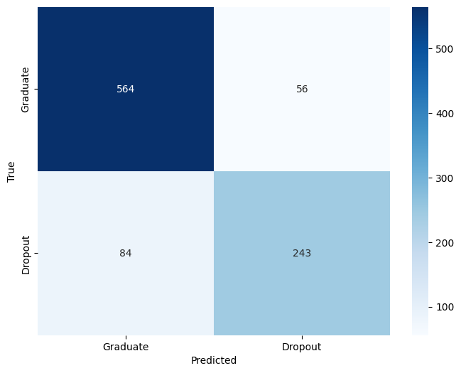

```
model =  XGBoost 	dataset =  SMOTE
Accuracy: 0.8543
Precision: 0.8435
Recall: 0.7294
F1 Score: 0.7823
```

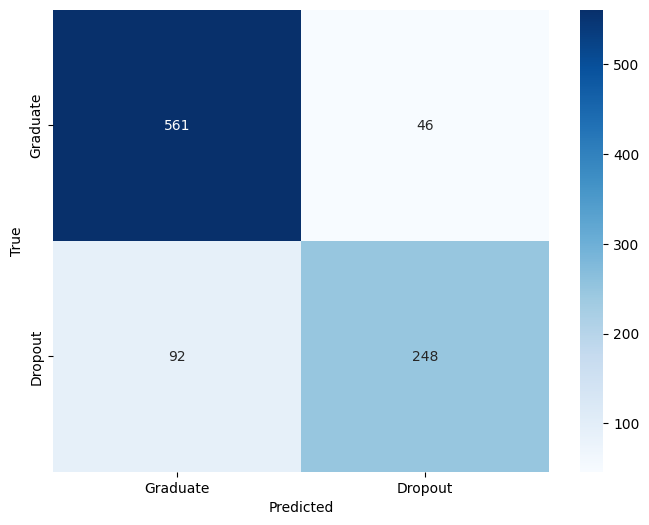

```
model =  XGBoost 	dataset =  RandomOverSampler
Accuracy: 0.8353
Precision: 0.8487
Recall: 0.7011
F1 Score: 0.7679
```

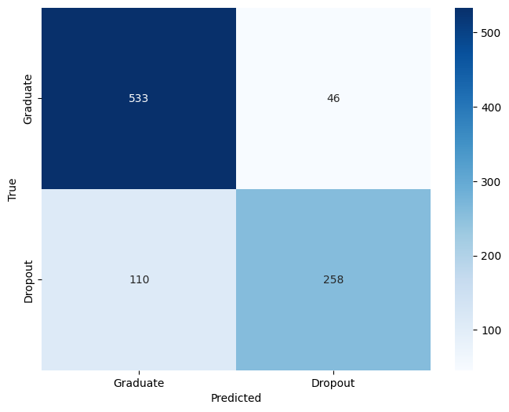

```
model =  XGBoost 	dataset =  ADASYN
Accuracy: 0.8501
Precision: 0.8328
Recall: 0.7421
F1 Score: 0.7848
```

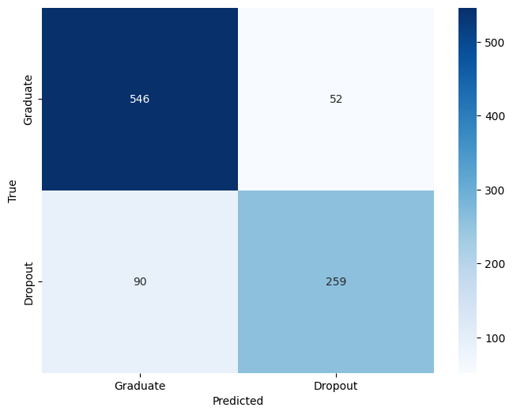

```
model =  XGBoost 	dataset =  RandomUnderSampler
Accuracy: 0.8501
Precision: 0.8276
Recall: 0.7229
F1 Score: 0.7717
```

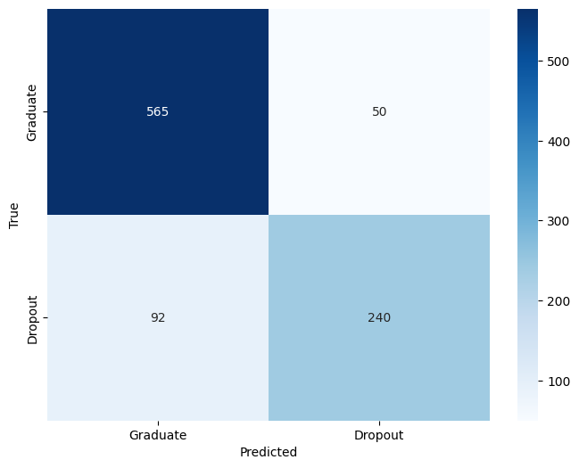

```python
model_name = 'XGBoost'
n_trees = 12
max_depth = 10
for data in Datasets.keys():
    print('model = ', model_name, '\tdataset = ', data)
    models[model_name].loc[data, 'Accuracy'], models[model_name].loc[data, 'Precision'], models[model_name].loc[data, 'Recall'],models[model_name].loc[data, 'F1'] = Helper.random_forest(X, y, n_estimators=n_trees, max_depth=max_depth, verbose=True)
```

## Random Forest and XGBoost—Using RFE Features

```python
X = X_ridge.copy()
```

### Random Forest

```python
from sklearn.metrics import accuracy_score
from sklearn.ensemble import RandomForestClassifier
from sklearn.model_selection import train_test_split

X_train_rf, X_test_rf, y_train_rf, y_test_rf = train_test_split(X, y, test_size=0.3)
# Creating Classifier - Random Forest
accuracy_rf = dict()
rf_models = dict()
for trees in range(2, 30):
    clf_rf = RandomForestClassifier(n_estimators=trees)
    clf_rf.fit(X_train_rf,y_train_rf)
    rf_models[trees] = clf_rf
    y_pred_rf=clf_rf.predict(X_test_rf)
    accuracy_rf[trees] = accuracy_score(y_test_rf, y_pred_rf)
accuracy_rf = dict(sorted(accuracy_rf.items(),key=(lambda x: x[1]), reverse= True))
accuracy_rf
```

```
{2: 0.8247096092925026,
 8: 0.8247096092925026,
 11: 0.82259767687434,
 3: 0.8215417106652587,
 24: 0.8204857444561774,
 14: 0.8194297782470961,
 26: 0.8194297782470961,
 12: 0.8183738120380147,
 18: 0.8183738120380147,
 10: 0.8173178458289335,
 27: 0.8173178458289335,
 28: 0.8173178458289335,
 6: 0.8141499472016895,
 13: 0.8141499472016895,
 20: 0.8141499472016895,
 22: 0.8141499472016895,
 29: 0.8141499472016895,
 17: 0.8130939809926082,
 23: 0.8130939809926082,
 16: 0.8109820485744457,
 19: 0.8109820485744457,
 21: 0.8109820485744457,
 7: 0.8099260823653643,
 15: 0.8099260823653643,
 4: 0.808870116156283,
 9: 0.8067581837381204,
 25: 0.8067581837381204,
 5: 0.8014783526927138}
```

```python
for model in accuracy_rf:
    y_pred_rf=rf_models[model].predict(X_test_rf)
    confusion_matrix_rf = pd.crosstab(y_test_rf, y_pred_rf, rownames=['Actual'], colnames=['Predicted'])
    print('Accuracy for i = {}: {} '.format(model, round(accuracy_score(y_test_rf, y_pred_rf), 4)))
    print(confusion_matrix_rf)
```

```
Accuracy for i = 2: 0.8247
Predicted    0    1
Actual
0          529   73
1           93  252
Accuracy for i = 8: 0.8247
Predicted    0    1
Actual
0          531   71
1           95  250
Accuracy for i = 11: 0.8226
Predicted    0    1
Actual
0          527   75
1           93  252
Accuracy for i = 3: 0.8215
Predicted    0    1
Actual
0          519   83
1           86  259
Accuracy for i = 24: 0.8205
Predicted    0    1
Actual
0          522   80
1           90  255
Accuracy for i = 14: 0.8194
Predicted    0    1
Actual
0          522   80
1           91  254
Accuracy for i = 26: 0.8194
Predicted    0    1
Actual
0          521   81
1           90  255
Accuracy for i = 12: 0.8184
Predicted    0    1
Actual
0          516   86
1           86  259
```

[output cut: 85 more lines]

```
Accuracy for i = 9: 0.8068
Predicted    0    1
Actual
0          507   95
1           88  257
Accuracy for i = 25: 0.8068
Predicted    0    1
Actual
0          509   93
1           90  255
Accuracy for i = 5: 0.8015
Predicted    0    1
Actual
0          503   99
1           89  256
```

although i = 2 has the best accuracy, i = 3 has a much better misclassification for our target class with slightly lower accuracy, hence going ahead with no of trees = 3

```
model =  Random_Forest 	dataset =  Unbalanced
Accuracy: 0.8321
Precision: 0.8357
Recall: 0.6809
F1 Score: 0.7504
```

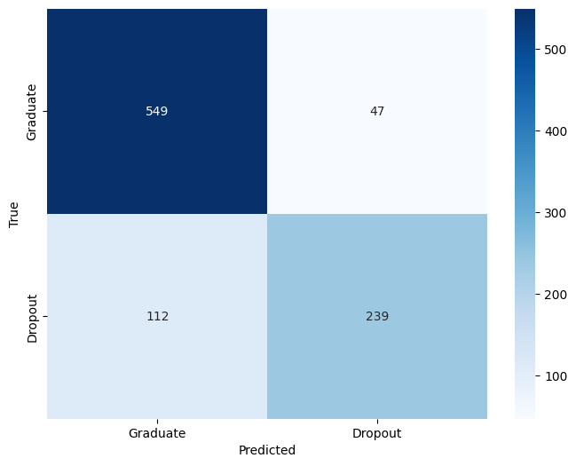

```
model =  Random_Forest 	dataset =  SMOTE
Accuracy: 0.8543
Precision: 0.8419
Recall: 0.7631
F1 Score: 0.8006
```

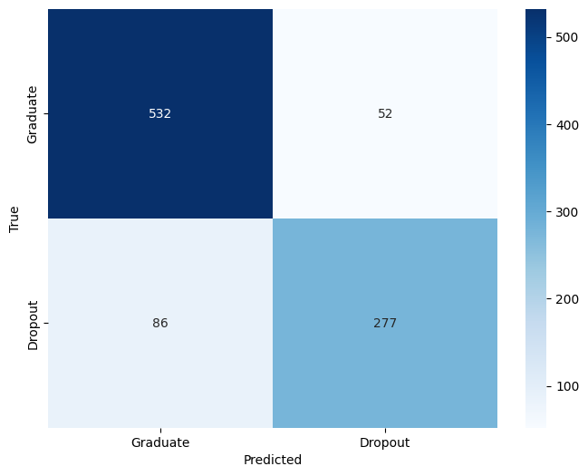

```
model =  Random_Forest 	dataset =  RandomOverSampler
Accuracy: 0.8458
Precision: 0.8268
Recall: 0.7312
F1 Score: 0.7761
```

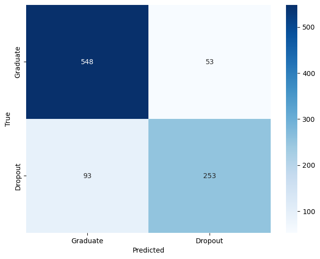

```
model =  Random_Forest 	dataset =  ADASYN
Accuracy: 0.8078
Precision: 0.8014
Recall: 0.6361
F1 Score: 0.7093
```

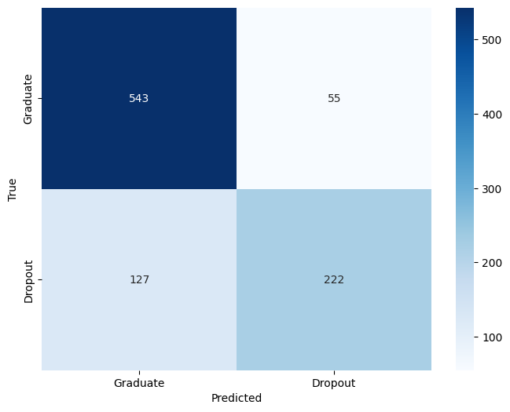

```
model =  Random_Forest 	dataset =  RandomUnderSampler
Accuracy: 0.8332
Precision: 0.8237
Recall: 0.7139
F1 Score: 0.7649
```

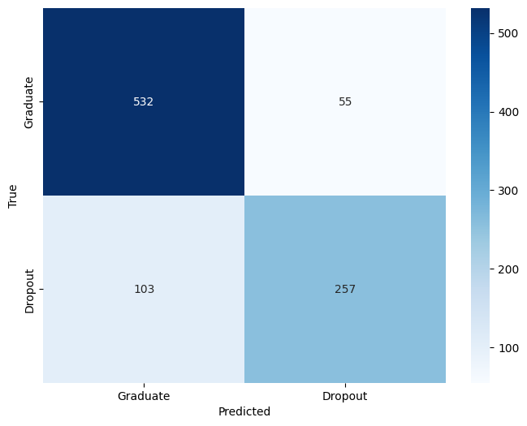

```python
model_name = 'Random_Forest'
n_trees = 3
max_depth = 10
for data in Datasets.keys():
    print('model = ', model_name, '\tdataset = ', data)
    models_rfe[model_name].loc[data, 'Accuracy'], models_rfe[model_name].loc[data, 'Precision'], models_rfe[model_name].loc[data, 'Recall'],models_rfe[model_name].loc[data, 'F1'] = Helper.random_forest(X, y, n_estimators=n_trees, max_depth=max_depth, verbose=True)
```

### XGBoost

```python
X_train_xgb, X_test_xgb, y_train_xgb, y_test_xgb = train_test_split(X, y, test_size=0.3)
# Creating Classifier - XGBoost
accuracy_xgb = dict()
xgb_models = dict()
for trees in range(2, 30):
    clf_xgb = XGBClassifier(n_estimators=trees)
    clf_xgb.fit(X_train_xgb,y_train_xgb)
    xgb_models[trees] = clf_xgb
    y_pred_xgb=clf_xgb.predict(X_test_xgb)
    accuracy_xgb[trees] = accuracy_score(y_test_xgb, y_pred_xgb)
accuracy_xgb = dict(sorted(accuracy_xgb.items(),key=(lambda x: x[1]), reverse= True))
accuracy_xgb
```

```
{9: 0.8521647307286166,
 10: 0.8521647307286166,
 11: 0.8521647307286166,
 13: 0.8521647307286166,
 16: 0.8521647307286166,
 17: 0.8511087645195353,
 18: 0.8511087645195353,
 19: 0.8511087645195353,
 20: 0.8511087645195353,
 21: 0.8511087645195353,
 22: 0.8511087645195353,
 23: 0.8511087645195353,
 24: 0.8511087645195353,
 25: 0.8511087645195353,
 26: 0.8511087645195353,
 27: 0.8511087645195353,
 28: 0.8511087645195353,
 14: 0.8500527983104541,
 15: 0.8500527983104541,
 6: 0.8489968321013728,
 5: 0.8479408658922915,
 7: 0.8468848996832101,
 12: 0.8468848996832101,
 2: 0.8458289334741288,
 3: 0.8458289334741288,
 8: 0.8458289334741288,
 29: 0.8458289334741288,
 4: 0.8447729672650475}
```

```python
for model in accuracy_xgb:
    y_pred_xgb=xgb_models[model].predict(X_test_xgb)
    confusion_matrix_xgb = pd.crosstab(y_test_xgb, y_pred_xgb, rownames=['Actual'], colnames=['Predicted'])
    print('Accuracy for i = {}: {} '.format(model, round(accuracy_score(y_test_xgb, y_pred_xgb), 4)))
    print(confusion_matrix_xgb)
```

```
Accuracy for i = 9: 0.8522
Predicted    0    1
Actual
0          566   31
1          109  241
Accuracy for i = 10: 0.8522
Predicted    0    1
Actual
0          566   31
1          109  241
Accuracy for i = 11: 0.8522
Predicted    0    1
Actual
0          566   31
1          109  241
Accuracy for i = 13: 0.8522
Predicted    0    1
Actual
0          566   31
1          109  241
Accuracy for i = 16: 0.8522
Predicted    0    1
Actual
0          562   35
1          105  245
Accuracy for i = 17: 0.8511
Predicted    0    1
Actual
0          561   36
1          105  245
Accuracy for i = 18: 0.8511
Predicted    0    1
Actual
0          563   34
1          107  243
Accuracy for i = 19: 0.8511
Predicted    0    1
Actual
0          563   34
1          107  243
```

[output cut: 85 more lines]

```
Accuracy for i = 8: 0.8458
Predicted    0    1
Actual
0          566   31
1          115  235
Accuracy for i = 29: 0.8458
Predicted    0    1
Actual
0          556   41
1          105  245
Accuracy for i = 4: 0.8448
Predicted    0    1
Actual
0          559   38
1          109  241
```

although i = 9 has the best accuracy, i = 14 has a much better misclassification for our target class with slightly lower accuracy, hence going ahead with no of trees = 14

```
model =  XGBoost 	dataset =  Unbalanced
Accuracy: 0.8300
Precision: 0.8007
Recall: 0.7101
F1 Score: 0.7527
```

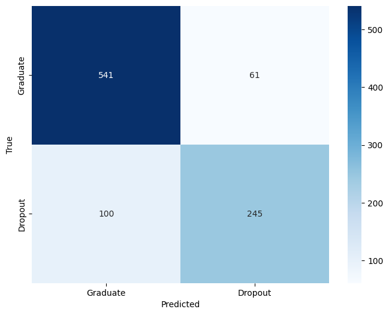

```
model =  XGBoost 	dataset =  SMOTE
Accuracy: 0.8511
Precision: 0.8257
Recall: 0.7404
F1 Score: 0.7807
```

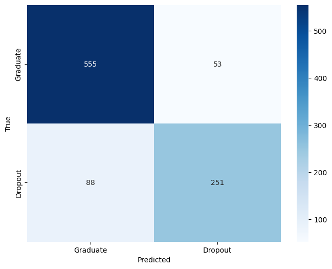

```
model =  XGBoost 	dataset =  RandomOverSampler
Accuracy: 0.8405
Precision: 0.7705
Recall: 0.7437
F1 Score: 0.7568
```

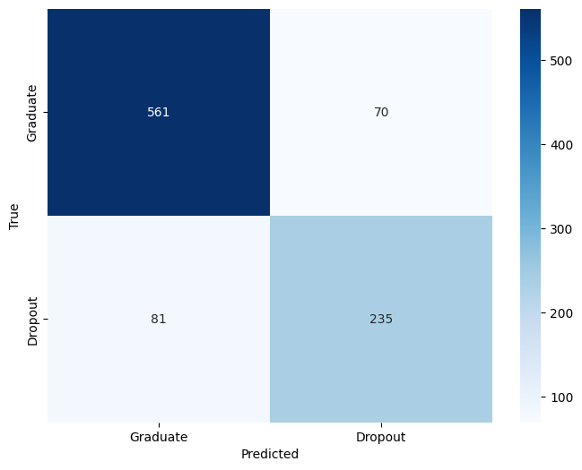

```
model =  XGBoost 	dataset =  ADASYN
Accuracy: 0.8416
Precision: 0.8404
Recall: 0.7187
F1 Score: 0.7748
```

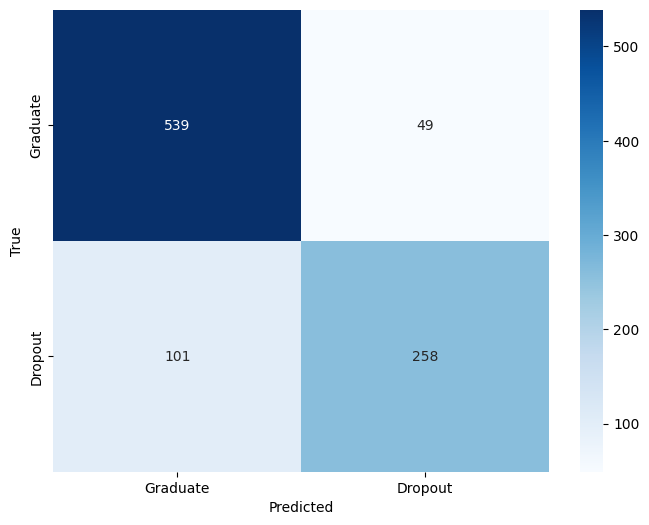

```
model =  XGBoost 	dataset =  RandomUnderSampler
Accuracy: 0.8353
Precision: 0.7888
Recall: 0.7427
F1 Score: 0.7651
```

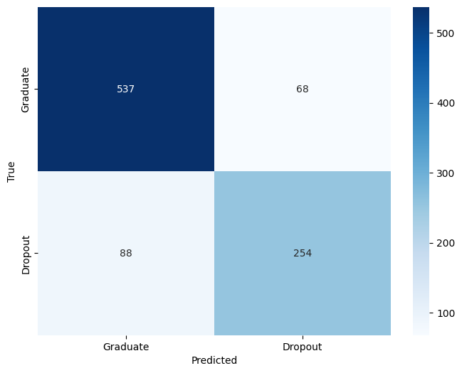

```python
model_name = 'XGBoost'
n_trees = 14
max_depth = 10
for data in Datasets.keys():
    print('model = ', model_name, '\tdataset = ', data)
    models_rfe[model_name].loc[data, 'Accuracy'], models_rfe[model_name].loc[data, 'Precision'], models_rfe[model_name].loc[data, 'Recall'],models_rfe[model_name].loc[data, 'F1'] = Helper.random_forest(X, y, n_estimators=n_trees, max_depth=max_depth, verbose=True)
```

## Comparing Models

```python
# pd.concat([models['LR_lasso'], models_rfe['LR_lasso']], keys=['Corr', 'RFE']).sort_values(by=['F1','Accuracy'], ascending=False)
```

```python
# pd.concat([models['LR_Ridge'], models_rfe['LR_Ridge']], keys=['Corr', 'RFE']).sort_values(by=['F1','Accuracy'], ascending=False)
```

```python
# pd.concat([models['Random_Forest'], models_rfe['Random_Forest']], keys=['Corr', 'RFE']).sort_values(by=['F1','Accuracy'], ascending=False)
```

```python
# pd.concat([models['XGBoost'], models_rfe['XGBoost']], keys=['Corr', 'RFE']).sort_values(by=['F1','Accuracy'], ascending=False)
```

### Logistic Regression - Lasso

```python
models['LR_lasso'].sort_values(by=['F1','Accuracy'], ascending=False)
```

|  | Accuracy | Precision | Recall | F1 |
| --- | --- | --- | --- | --- |
| RandomOverSampler | 0.870116 | 0.910112 | 0.710526 | 0.798030 |
| ADASYN | 0.863780 | 0.883392 | 0.722543 | 0.794913 |
| Unbalanced | 0.844773 | 0.872727 | 0.681818 | 0.765550 |
| SMOTE | 0.843717 | 0.851986 | 0.688047 | 0.761290 |
| RandomUnderSampler | 0.840549 | 0.841897 | 0.657407 | 0.738302 |

The above results are for logistic regression with lasso penalty, using the feature set selected by the correlation matrix. From this result we can see that although the 'Random Over Sampler' dataset provides a better accuracy, the 'ASASYN' dataset provides a similar accuracy with a greater recall, meaning that it has a lower number of misclassifications for 'Dropout' cases, which is important for our use case.

```python
models_rfe['LR_lasso'].sort_values(by=['F1','Accuracy'], ascending=False)
```

|  | Accuracy | Precision | Recall | F1 |
| --- | --- | --- | --- | --- |
| RandomUnderSampler | 0.854277 | 0.919847 | 0.673184 | 0.777419 |
| RandomOverSampler | 0.855333 | 0.880309 | 0.682635 | 0.768971 |
| SMOTE | 0.845829 | 0.934426 | 0.636872 | 0.757475 |
| Unbalanced | 0.827878 | 0.920455 | 0.631169 | 0.748844 |
| ADASYN | 0.826822 | 0.882591 | 0.617564 | 0.726667 |

The above results are for logistic regression with lasso penalty, using the feature set selected by RFE method. From this result, we can see that the 'Random Over Sampler' dataset provides a better accuracy, as well as recall.

### Logistic Regression - Ridge

```python
models['LR_Ridge'].sort_values(by=['F1','Accuracy'], ascending=False)
```

|  | Accuracy | Precision | Recall | F1 |
| --- | --- | --- | --- | --- |
| RandomOverSampler | 0.837381 | 0.910204 | 0.628169 | 0.743333 |
| ADASYN | 0.840549 | 0.876543 | 0.637725 | 0.738302 |
| RandomUnderSampler | 0.842661 | 0.878151 | 0.635258 | 0.737213 |
| SMOTE | 0.824710 | 0.890295 | 0.601140 | 0.717687 |
| Unbalanced | 0.825766 | 0.865741 | 0.578947 | 0.693878 |

The above results are for logistic regression with ridge penalty, using the feature set selected by the correlation matrix. From this result, we can see that although the 'Random Over Sampler' dataset provides a better F1 score, the 'ASASYN' dataset provides a similar F1 score with a greater recall.

```python
models_rfe['LR_Ridge'].sort_values(by=['F1','Accuracy'], ascending=False)
```

|  | Accuracy | Precision | Recall | F1 |
| --- | --- | --- | --- | --- |
| ADASYN | 0.854277 | 0.864769 | 0.708455 | 0.778846 |
| RandomOverSampler | 0.853221 | 0.841912 | 0.704615 | 0.767169 |
| RandomUnderSampler | 0.845829 | 0.823529 | 0.695652 | 0.754209 |
| SMOTE | 0.835269 | 0.870722 | 0.652422 | 0.745928 |
| Unbalanced | 0.837381 | 0.865900 | 0.655072 | 0.745875 |

### Random Forest

```python
models['Random_Forest'].sort_values(by=['F1','Accuracy'], ascending=False)
```

|  | Accuracy | Precision | Recall | F1 |
| --- | --- | --- | --- | --- |
| RandomOverSampler | 0.865892 | 0.851974 | 0.759531 | 0.803101 |
| Unbalanced | 0.871172 | 0.835017 | 0.772586 | 0.802589 |
| ADASYN | 0.852165 | 0.839228 | 0.743590 | 0.788520 |
| SMOTE | 0.850053 | 0.828571 | 0.747851 | 0.786145 |
| RandomUnderSampler | 0.852165 | 0.849498 | 0.727794 | 0.783951 |

Looking at this result, we can see a significant improvement as compared to the logistic regression models. The above results are for random forests, using the feature set selected by the correlation matrix. From this result, we can see that although the 'Random Over Sampler' dataset provides a better F1 score, the 'Unbalanced' dataset provides a similar F1 score with greater recall and accuracy. This is the best model of all the models that we have tried.

```python
models_rfe['Random_Forest'].sort_values(by=['F1','Accuracy'], ascending=False)
```

|  | Accuracy | Precision | Recall | F1 |
| --- | --- | --- | --- | --- |
| SMOTE | 0.854277 | 0.841945 | 0.763085 | 0.800578 |
| RandomOverSampler | 0.845829 | 0.826797 | 0.731214 | 0.776074 |
| RandomUnderSampler | 0.833157 | 0.823718 | 0.713889 | 0.764881 |
| Unbalanced | 0.832101 | 0.835664 | 0.680912 | 0.750392 |
| ADASYN | 0.807814 | 0.801444 | 0.636103 | 0.709265 |

The above results are for random forests, using the feature set selected by RFE method. From this result, we can see that the 'SMOTE' dataset comes out on the top in all the evaluation parameters

### XGBoost

```python
models['XGBoost'].sort_values(by=['F1','Accuracy'], ascending=False)
```

|  | Accuracy | Precision | Recall | F1 |
| --- | --- | --- | --- | --- |
| ADASYN | 0.850053 | 0.832797 | 0.742120 | 0.784848 |
| SMOTE | 0.854277 | 0.843537 | 0.729412 | 0.782334 |
| Unbalanced | 0.852165 | 0.812709 | 0.743119 | 0.776358 |
| RandomUnderSampler | 0.850053 | 0.827586 | 0.722892 | 0.771704 |
| RandomOverSampler | 0.835269 | 0.848684 | 0.701087 | 0.767857 |

```python
models_rfe['XGBoost'].sort_values(by=['F1','Accuracy'], ascending=False)
```

|  | Accuracy | Precision | Recall | F1 |
| --- | --- | --- | --- | --- |
| SMOTE | 0.851109 | 0.825658 | 0.740413 | 0.780715 |
| ADASYN | 0.841605 | 0.840391 | 0.718663 | 0.774775 |
| RandomUnderSampler | 0.835269 | 0.788820 | 0.742690 | 0.765060 |
| RandomOverSampler | 0.840549 | 0.770492 | 0.743671 | 0.756844 |
| Unbalanced | 0.829989 | 0.800654 | 0.710145 | 0.752688 |

## Conclusion

Looking at the above results we can conclude a few things:

1. We expected balanced datasets to outperform unbalanced datasets, but there was no significant difference and the best model that we got was for an unbalanced dataset.
2. Contrary to our expectations, the boosting method did not provide any significant improvement. Their results were at par with random forest, with random forest performing slightly better.
3. Random forest models consistently outperformed both l1 and l2 logistic regression models which was consistent with our expectations.
4. Although at first glance, logistic regression models had a very good accuracy, at par with random forest, there was a huge imbalance in the precision and recall. They had very good precision with poor recall, which is not beneficial for our use case.
5. Apart from Ridge logistic regression, for all other methods, the correlation matrix feature selection method provided better results as compared to 'Recursive Forward Elimination'.